# Introduction to Tableau

**ONS / NISR**  
2021

## Overview

- What is Tableau?
- How can we use it?

### Getting Started

- Importing Data
- Creating Visualisations
- Creating Dashboards and Stories
- Publishing

## What is Tableau?

Tableau is a dashboarding tool that makes it incredibly easy to create complex, interactive visualisations in a **low-code** way.

Tableau can optimise for whatever type of device is being used (computer, phone, tablet) meaning it always looks good.

Tableau can be used to make complex interactive dashboards for nearly any data source.

Tableau can be easily embedded on any webpage, or downloaded into a standalone file offline viewing

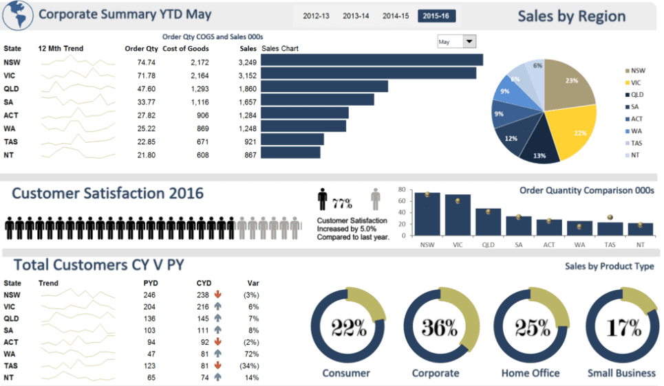

## Getting Started

### Importing Data

Tableau can connect to many different types of data, either directly as **files** or via a **database** on a server. *For Files*

- Launch Tableau
- Under the **connect** pane select the file type your planning to work with. Text files includes .CSVs and .TSVs etc.
- Navigate to the file using the file select dialog and click open.

*For Databases*

- Connections to live databases aren't available in Tableau public
- But connections to Google Drive and Google Sheets are available under *To a Server > More...*

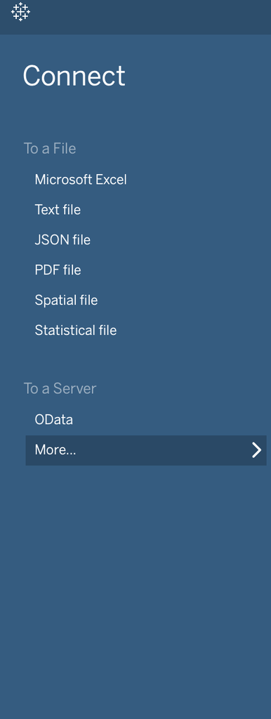